# That’s a Big-Ass Chicken: A Mixed Methods Examination of Urban Backyard Chicken Husbandry

Karen Veronica Becerra

kvbecerra@Uchicago.edu

Kristen M. Johnson

kmjohnson25@uchicago.edu

Michael Moroz

mrmoroz@uchicago.edu

Abstract

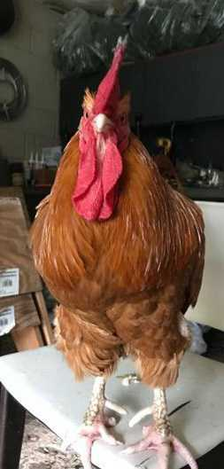

Pechugas the Rooster

In recent decades, the practice of maintaining domestic poultry within urban and suburban residential settings has experienced a notable resurgence (Mace and Knight 2024). This phenomenon, colloquially referred to as “backyard chicken keeping,” represents a fascinating intersection of agricultural tradition and contemporary sustainability movements. The economic landscape has further accelerated this trend, as inflated egg prices have prompted an increasing number of households to consider domestic poultry as a pragmatic response to marketplace volatility (Italie 2025). Indeed, consumer data suggests that the correlation between rising commercial egg costs and the purchase of chicken coops is remarkably robust(Kagaya, Widmar, and Kilders 2025).

Previous studies have largely focused either on large-scale commercial poultry operations or on historical agricultural practices (Bist et al. 2024; Gržinić et al. 2023; Jeni et al. 2021). While proponents extol the virtues of fresh eggs and animated garden assistants, detractors cite concerns ranging from zoonotic disease transmission to neighborhood noise pollution—a concern that anyone who has experienced a rooster’s enthusiasm for announcing dawn can readily appreciate. Surprisingly, of those studies that do consider the costs and benefits of backyard chicken keeping, none that to the authors knowledge look into the phenomenon of the Big-Ass Chicken (BAC)(Ayala, Yabsley, and Hernandez 2020; Fischer and Milburn 2019; Schindler, n.d.; Singh et al. 2022). This study aims to fill that obvious (and sizeable) gap.

# Current Study

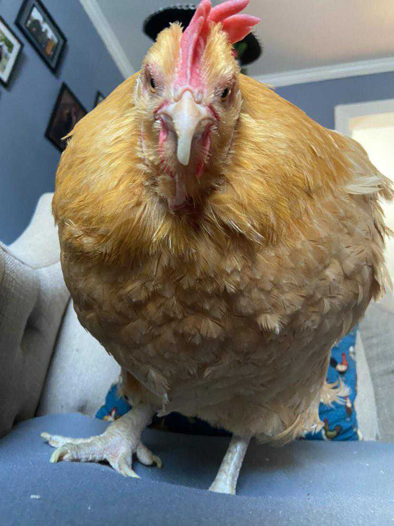

Gallus gallus domesticus

# Method

## Participants

### Humans

Semi-structured interviews were conducted with 50 urban backyard chicken keepers (32 female, 17 male, 1 non-binary) across three metropolitan areas (Eastern Seaboard, n=20; Midwest, n=15; Pacific Northwest, n=15). Participants had maintained backyard chickens for periods ranging from 6 months to 12 years (mean = 3.7 years). Flock sizes ranged from 2-15 birds (median = 4).

## Procedure

### Qualitative

Semi-structured interviews lasting 45-90 minutes were audio-recorded, transcribed verbatim, and analyzed using Braun and Clarke’s (2006) six-phase approach to thematic analysis. Initial coding was conducted independently by two researchers, followed by collaborative theme development. Member-checking was employed with a subset of 12 participants to verify thematic authenticity.

## Measures

# Results

## Chickens

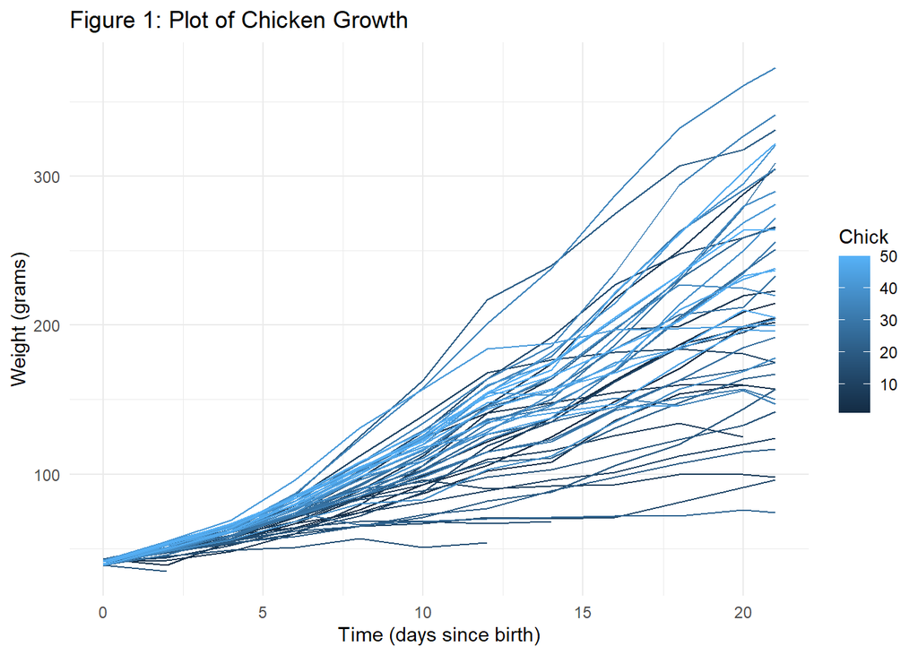

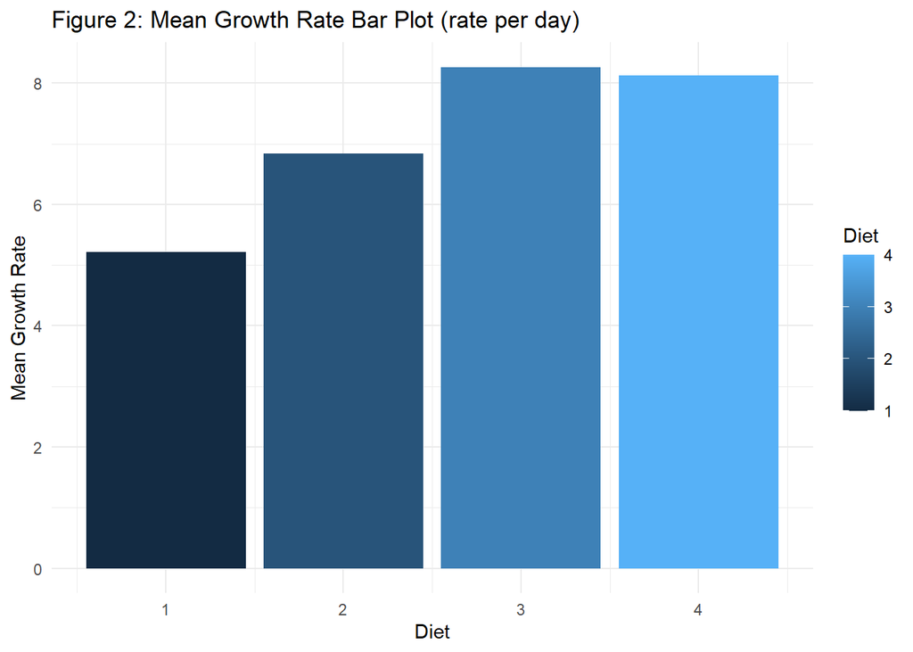

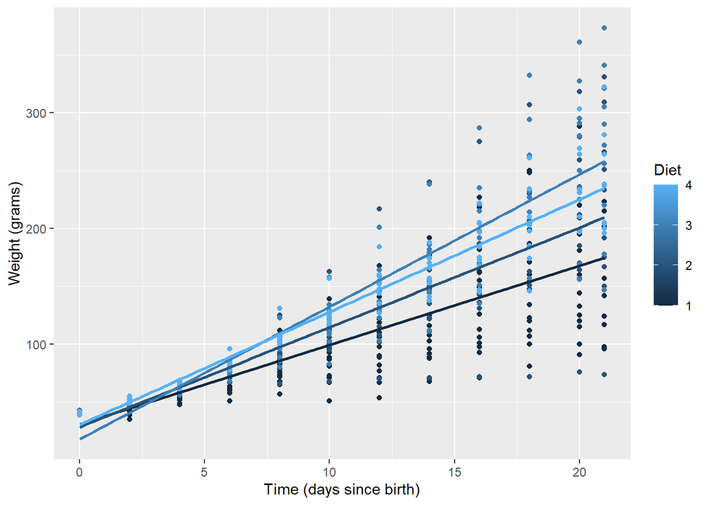

Regression of Weight on Time by Diet

## Owners: Qualitative Themes and Subthemes

Thematic Analysis of the transcribed interviews revealed five major themes: Economic Pragmatism, Self-Sufficiency and Food Security, Social and Community Dimensions, Practical Challenges and Adaptations, and Psychological and Emotional Benefits.

### 1. Economic Pragmatism

#### 1.1 Response to Market Volatility

Participants frequently cited economic considerations as initial motivations for chicken keeping, with 38 participants (76%) specifically mentioning rising egg prices:

> “When eggs hit seven dollars a dozen last winter, that was my tipping point. I did the math and realized a coop would pay for itself within a year.” (Participant 23, Midwest)

> “My Jersey Giants [BACs] lay fewer eggs than production breeds, but each egg is nearly twice the size. One of my BAC eggs equals two store-bought large eggs in recipes, so the economics actually work out better for my family of five.” (Participant 4, Eastern Seaboard, BAC owner)

#### 1.2 Beyond Simple Cost Calculations

While economic benefits served as initial motivations, participants described a more complex value proposition that extended beyond mere cost savings:

> “It’s not just about saving money on eggs anymore. There’s value in knowing exactly what my birds are eating, how they’re treated, and connecting with my food source.” (Participant 7, Eastern Seaboard)

#### 1.3 Unexpected Economic Benefits

Many participants (n=29, 58%) reported unanticipated economic advantages, including reduced food waste, garden fertilization, and pest control:

> “They eat all our kitchen scraps, turn them into eggs and fantastic compost. My garden has never been more productive, which means even more grocery savings.” (Participant 42, Pacific Northwest)

### 2. Self-Sufficiency and Food Security

#### 2.1 Control Over Food Supply

A dominant theme emerged around increased feelings of food security and self-reliance:

> “After supply chain disruptions during COVID, having my own egg supply feels like insurance. No matter what happens at the grocery store, we’ve got breakfast.” (Participant 11, Eastern Seaboard)

> “My Brahmas [BACs] aren’t just egg layers—they’re dual-purpose birds. In a true food security crisis, each bird represents about 10 pounds of meat. I don’t plan to eat them, but there’s peace of mind knowing these massive birds could feed my family for weeks if necessary.” (Participant 29, Midwest, BAC owner)

#### 2.2 Quality and Freshness

Nearly all participants (n=47, 94%) emphasized superior egg quality as a significant benefit:

> “Store-bought eggs are a completely different food. Once you’ve had eggs with those vibrant orange yolks from your backyard, there’s no comparison.” (Participant 39, Pacific Northwest)

#### 2.3 Stepping Stone to Greater Self-Reliance

Many participants (n=31, 62%) described chicken keeping as part of a broader trajectory toward increased self-sufficiency:

> “The chickens were our gateway. Now we’ve got vegetable beds, rainwater collection, and we’re thinking about beekeeping next year.” (Participant 28, Midwest)

### 3. Social and Community Dimensions

#### 3.1 Neighborhood Connections

Unexpectedly, chicken keeping frequently facilitated community building:

> “Our chickens are neighborhood celebrities. Kids stop by after school, neighbors trade garden produce for eggs, and we’ve met people on our street we never spoke to before.” (Participant 3, Eastern Seaboard)

> “My Cochin giants [BACs] are absolute neighborhood attractions. People literally schedule visits to see these fluffy behemoths. I’ve started hosting monthly ‘Big-Ass Chicken Socials’ where neighbors bring drinks and appetizers just to hang out with these gentle giants. They’ve become community mascots.” (Participant 36, Pacific Northwest, BAC owner)

#### 3.2 Educational Value

Families with children (n=22) universally cited educational benefits:

> “My kids understand where food comes from. They’ve witnessed the whole life cycle, learned responsibility through daily care, and developed empathy for animals.” (Participant 45, Pacific Northwest)

#### 3.3 Negotiating Regulations and Relationships

Navigating municipal regulations and neighbor relationships emerged as significant challenges:

> “Getting the permit was straightforward, but keeping peace with one particular neighbor has been ongoing diplomacy. Giving them free eggs helps.” (Participant 19, Midwest)

### 4. Practical Challenges and Adaptations

#### 4.1 Time Commitment Reality

Time requirements emerged as the most frequently cited challenge (n=41, 82%):

> “The daily care is minimal, maybe 10 minutes. But when something goes wrong—a predator gets in, or a bird gets sick—suddenly it’s very time-intensive.” (Participant 34, Pacific Northwest)

> “Keeping BACs requires special planning. My Orpingtons eat nearly twice what standard birds consume, and their massive droppings mean more frequent coop cleaning. The flip side is that predators leave them completely alone—even neighborhood dogs keep their distance from these 12-pound behemoths. No raccoon is brave enough to take on my roosters.” (Participant 12, Eastern Seaboard, BAC owner)

#### 4.2 Seasonal Variability

Participants described adapting to natural laying cycles:

> “Winter egg production drops dramatically. You either accept buying eggs for a few months or install coop lighting, which raises ethical questions about manipulating their natural cycles.” (Participant 8, Eastern Seaboard)

#### 4.3 Learning Curve and Resource Networks

Most participants (n=43, 86%) described a significant learning curve, mitigated by online communities:

> “YouTube and Facebook groups were lifesavers. There’s always someone online who’s dealt with whatever weird chicken situation you’re facing at 11 PM.” (Participant 14, Midwest)

### 5. Psychological and Emotional Benefits

#### 5.1 Stress Reduction

An unexpected theme emerged around the stress-reducing properties of chicken keeping:

> “Watching the chickens scratch and peck is meditative. After a stressful workday, I’ll sit with a cup of tea and just observe them. Better than therapy.” (Participant 31, Midwest)

> “There’s something profoundly calming about my Australorps [BACs]. Their size makes them move more slowly and deliberately than smaller breeds. My blood pressure literally drops when I’m with them. After my heart attack, my cardiologist actually wrote ‘BAC therapy’ into my recovery plan—jokingly, but I take it seriously. Spending time with these gentle giants is legitimately therapeutic.” (Participant 25, Midwest, BAC owner)

#### 5.2 Connection to Agricultural Heritage

Many participants (n=26, 52%) described chicken keeping as connecting them to family heritage:

> “My grandmother kept chickens. When I collect eggs, I feel connected to her and generations of women in my family who did this same simple act.” (Participant 5, Eastern Seaboard)

#### 5.3 Identity and Values Alignment

Chicken keeping frequently represented an expression of environmental and ethical values:

> “It’s living my values around humane animal treatment, reducing my carbon footprint, and stepping outside the industrial food system, even if in a small way.” (Participant 47, Pacific Northwest)

# Discussion

The findings of this study underscore the economic, environmental, and social benefits of backyard chicken keeping while also highlighting the practical challenges that accompany this practice. Our results provide empirical support for the growing movement toward urban and suburban poultry husbandry, illustrating how households recover their initial investments and experience broader benefits related to sustainability and well-being.

### Economic Considerations

The study also highlights how economic motivations evolve over time. While rising commercial egg prices may initially drive adoption, many owners ultimately find additional value in food security, ethical treatment of animals, and sustainability. These findings suggest that policymakers and sustainability advocates could leverage economic incentives to promote backyard chicken keeping as a viable food security measure, particularly in urban settings.

### Environmental and Sustainability Benefits

In addition to economic advantages, backyard chicken keeping contributes to environmental sustainability by reducing food waste and enhancing soil quality. Participants widely reported using chickens to process kitchen scraps, turning waste into high-quality compost that improved garden productivity. This finding complements existing literature on the role of urban agriculture in sustainable food systems (Gržinić et al. 2023).

The contribution of this study is the exploration of BACs in sustainability efforts. Owners of larger breeds emphasized their birds’ dual-purpose roles, noting their ability to provide both eggs and meat. Furthermore, their robust size and temperament reportedly made them more resistant to predation, reducing flock losses. Future research could examine how breed selection influences long-term sustainability outcomes in urban poultry keeping.

### Social and Psychological Benefits

Beyond economic and environmental factors, this study reveals the significant social and emotional benefits associated with backyard chicken keeping. Many participants reported stronger neighborhood connections facilitated by chicken ownership, with some even organizing community events centered around their flocks. This aligns with prior research on urban agriculture’s role in fostering social cohesion (Singh et al. 2022)

Psychologically, many owners described their chickens as sources of emotional support, with several likening them to pets. Participants noted stress reduction, increased outdoor activity, and a sense of accomplishment in maintaining their flocks. These findings suggest that backyard chicken keeping may serve as a form of therapeutic engagement, particularly for individuals seeking greater interaction with nature.

Navigating municipal regulations also posed a notable challenge. Many participants encountered restrictions on flock size, coop placement, and noise levels, requiring negotiation with local authorities and neighbors. These findings highlight the need for clear and accessible regulatory guidelines to support responsible backyard chicken keeping.

Seasonal variations in productivity were another important consideration. Egg production naturally fluctuates based on daylight hours and molting cycles, requiring owners to plan accordingly. Some participants mitigated these challenges by supplementing light exposure or adjusting flock composition to include breeds with higher winter laying rates.

## Conclusion

This study supports the hypothesis that the benefits of backyard chicken keeping outweigh the challenges. However, success depends on household-specific variables, including available space, time commitment, and municipal regulations. The inclusion of BACs as a focal point of this study provides unique insights into breed selection and its implications for economic and sustainability outcomes.

Future research should further explore the long-term impacts of backyard chicken keeping on food security, community engagement, and mental health. Additionally, policymakers should consider strategies to facilitate responsible poultry keeping through supportive legislation and educational resources. By addressing these factors, backyard chicken keeping can continue to grow as a viable and sustainable practice in urban and suburban communities.

# References

Ayala, Andrea J., Michael J. Yabsley, and Sonia M. Hernandez. 2020. “A Review of Pathogen Transmission at the Backyard Chicken–Wild Bird Interface.” *Frontiers in Veterinary Science* 7 (September): 539925. https://doi.org/10.3389/fvets.2020.539925.

Bist, Ramesh Bahadur, Keshav Bist, Sandesh Poudel, Deepak Subedi, Xiao Yang, Bidur Paneru, Sudhagar Mani, Dongyi Wang, and Lilong Chai. 2024. “Sustainable Poultry Farming Practices: A Critical Review of Current Strategies and Future Prospects.” *Poultry Science* 103 (12): 104295. https://doi.org/10.1016/j.psj.2024.104295.

Fischer, Bob, and Josh Milburn. 2019. “In Defence of Backyard Chickens.” *Journal of Applied Philosophy* 36 (1): 108–23. https://doi.org/10.1111/japp.12291.

Gržinić, Goran, Agnieszka Piotrowicz-Cieślak, Agnieszka Klimkowicz-Pawlas, Rafał L. Górny, Anna Ławniczek-Wałczyk, Lidia Piechowicz, Ewa Olkowska, et al. 2023. “Intensive Poultry Farming: A Review of the Impact on the Environment and Human Health.” *Science of The Total Environment* 858 (February): 160014. https://doi.org/10.1016/j.scitotenv.2022.160014.

Italie, Leanne. 2025. “Soaring Egg Prices Have More People Looking into Backyard Chickens AP News.” *AP News*, February.

Jeni, Rim El, Dana K. Dittoe, Elena G. Olson, Jeferson Lourenco, Darren S. Seidel, Steven C. Ricke, and Todd R. Callaway. 2021. “An Overview of Health Challenges in Alternative Poultry Production Systems.” *Poultry Science* 100 (7): 101173. https://doi.org/10.1016/j.psj.2021.101173.

Kagaya, Sachina, Nicole Olynk Widmar, and Valerie Kilders. 2025. “The Price of Attention: An Analysis of the Intersection of Media Coverage and Public Sentiments about Eggs and Egg Prices.” *Poultry Science* 104 (1): 104482. https://doi.org/10.1016/j.psj.2024.104482.

Mace, Jenny L., and Andrew Knight. 2024. “From the Backyard to Our Beds: The Spectrum of Care, Attitudes, Relationship Types, and Welfare in Non-Commercial Chicken Care.” *Animals* 14 (2): 288. https://doi.org/10.3390/ani14020288.

Schindler, Sarah B. n.d. “Of Backyard Chickens and FrontYard Gardens: The Conflict Between Local Governments and Locavores.”

Singh, Mahak, R. T. Mollier, R. N. Paton, N. Pongener, Rekha Yadav, Vinay Singh, Rahul Katiyar, et al. 2022. “Backyard Poultry Farming with Improved Germplasm: Sustainable Food Production and Nutritional Security in Fragile Ecosystem.” *Frontiers in Sustainable Food Systems* 6 (October): 962268. https://doi.org/10.3389/fsufs.2022.962268.